# CreditCard_Fraud_3

## Step 3: Model Optimization, Interpretation & Advanced Evaluation

**Add Explainable AI (XAI) Using SHAP**

I use SHAP to understand how my Random Forest model makes fraud predictions. It shows how much each feature contributes to pushing a transaction toward fraud or non-fraud, providing transparency into the model’s decision-making. This allows me to validate the model’s behavior, detect potential biases, and clearly explain individual predictions to stakeholders.

```python
# Install packages

!pip install shap
import shap
import numpy as np
import pandas as pd
%matplotlib inline
shap.initjs()  # enables JS rendering for force plot
import joblib
```

```python
# Load saved model artefacts from Part 2 #

artifacts = joblib.load("fraud_randomforest_artifacts.pkl")

rf = artifacts["rf"]
best_threshold = artifacts["best_threshold"]
feature_names = artifacts["feature_names"]
C_FN = artifacts["C_FN"]
C_FP = artifacts["C_FP"]
X_test_scaled = artifacts["X_test_scaled"]
y_test = artifacts["y_test"]
X_train_res = artifacts["X_train_res"]
y_train_res = artifacts["y_train_res"]
y_train = artifacts["y_train"]
X_train_scaled = artifacts["X_train_scaled"]
```

```python
# Ensure X_test_scaled is a DataFrame with correct column names

if not isinstance(X_test_scaled, pd.DataFrame):
    X_test_scaled = pd.DataFrame(X_test_scaled, columns=feature_names)
```

```python
# Sample for global SHAP (increase speed processing)

N_SHAP = min(500, len(X_test_scaled))
X_shap = X_test_scaled.sample(n=N_SHAP, random_state=42)
```

```python
# Create TreeExplainer for the Random Forest

explainer = shap.TreeExplainer(rf)

# Compute SHAP values for the test set

shap_values = explainer.shap_values(X_shap)  # shap_values[0]=class 0, shap_values[1]=class 1
shap_values_class1 = shap_values[:, :, 1]  # shape: (500, 33)

print("X_shap shape:", X_shap.shape)
print("SHAP values shape (class 1):", shap_values_class1.shape)  # should match X_shap shape
```

```
X_shap shape: (500, 33)
SHAP values shape (class 1): (500, 33)
```

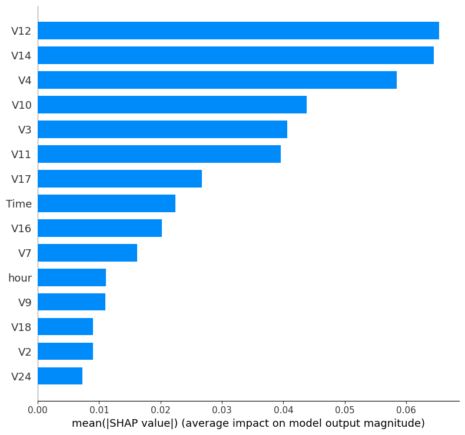

```python
# Global Feature Importance (Bar Plot)

shap.summary_plot(
    shap_values_class1,
    X_shap,
    plot_type="bar",
    max_display=15
)
```

*Interpretation of the SHAP Bar Plot*

This SHAP bar plot shows the average contribution of each feature to the model’s fraud prediction. Features like V12, V14, V4, V10, and V3 have the largest SHAP values, meaning they consistently have the strongest influence in determining whether a transaction is classified as fraud. In practical terms, these variables drive most of the model’s decision-making, while features toward the bottom (e.g., V24, V2, V18) have much smaller impact and play a limited role in predictions.

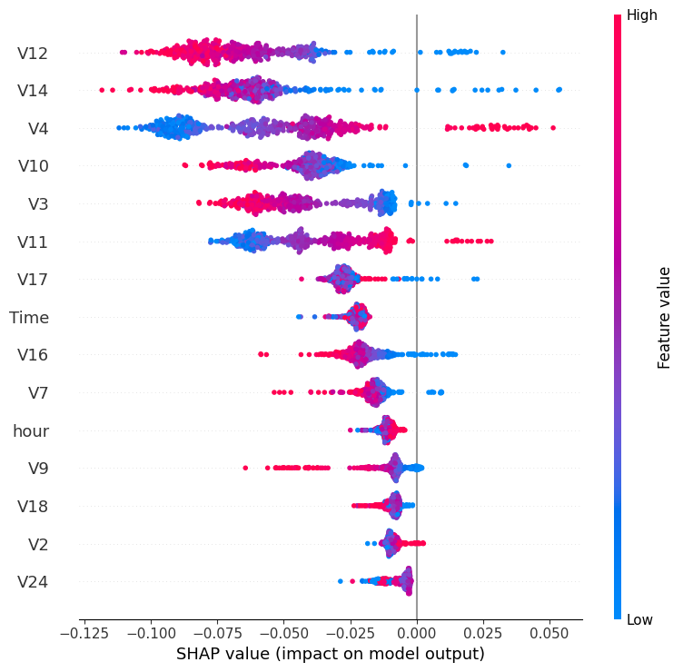

```python
# SHAP Beeswarm Plot

shap.summary_plot(
    shap_values_class1,
    X_shap,
    max_display=15
)
```

*Interpretation of the SHAP Beeswarm Plot*

This SHAP beeswarm plot shows how each feature influences the model’s fraud predictions across all transactions. Each dot represents one transaction, and the color indicates whether that feature’s value was high (red) or low (blue).

```python
# Select one fraud example from the test set
fraud_idx = np.where(y_test == 1)[0][0] # finds all indexes where the label is fraud (class = 1) + selects the first fraud example [0][0]
fraud_case = X_test_scaled.iloc[[fraud_idx]]  # retrieves that row as a DataFrame, not a Series — SHAP requires a 2-D input.

# Compute SHAP for this single row
shap_values_single = explainer.shap_values(fraud_case)

# Extract values for class 1 (Fraud)
shap_values_single_class1 = shap_values_single[:, :, 1] if shap_values_single.ndim == 3 else shap_values_single[1]
```

```python
# Force plot

shap.force_plot(
    explainer.expected_value[1],
    shap_values_single_class1[0],
    fraud_case.iloc[0]
)
```

[output not shown]

```python
# Save SHAP results

joblib.dump(
    {
        "X_shap": X_shap,
        "shap_values": shap_values_shap
    },
    "shap_global_results.pkl"
)
```

```
['shap_global_results.pkl']
```

**Add a Deep Learning Model (Fully Connected Neural Network)**

The aim is to build a machine learning pipeline for a classification problem where classes are imbalanced (one class appears much more than the other). The plan is to:

- Train a Deep Learning model (Fully Connected Neural Network / MLP) using TensorFlow/Keras.
- Apply class weighting to address the imbalance.
- Keep a clean 3-layer architecture for the neural network.
- Compare the performance against a Random Forest classifier using precision/recall/F1

```python
!pip install tensorflow

import tensorflow as tf
from tensorflow import keras
from tensorflow.keras import layers
from sklearn.utils.class_weight import compute_class_weight
import numpy as np
```

[output not shown]

When you have imbalanced classes, the model might just predict the majority class all the time. To fix this, you can assign more weight to the minority class so the model “pays more attention” to it.

```python
# Compute class weights (important for imbalanced dataset)

class_weights = compute_class_weight( # automatically calculates weights inversely proportional to class frequency.
    class_weight='balanced',
    classes=np.unique(y_train),
    y=y_train
)

class_weights = {i : class_weights[i] for i in range(len(class_weights))}
print("Class Weights:", class_weights)
```

```
Class Weights: {0: np.float64(0.5008661206149896), 1: np.float64(289.14340101522845)}
```

```python
# Build a simple neural network

model_nn = keras.Sequential([
    layers.Dense(32, activation='relu', input_shape=(X_train_scaled.shape[1],)),
    layers.Dropout(0.3),

    layers.Dense(16, activation='relu'),
    layers.Dropout(0.2),

    layers.Dense(1, activation='sigmoid')   # binary classification
])

model_nn.compile(
    optimizer='adam',
    loss='binary_crossentropy',
    metrics=['accuracy', keras.metrics.Precision(), keras.metrics.Recall()]
)

model_nn.summary()
```

```
Model: "sequential"
```

```
┏━━━━━━━━━━━━━━━━━━━━━━━━━━━━━━━━━┳━━━━━━━━━━━━━━━━━━━━━━━━┳━━━━━━━━━━━━━━━┓
┃ Layer (type)                    ┃ Output Shape           ┃       Param # ┃
┡━━━━━━━━━━━━━━━━━━━━━━━━━━━━━━━━━╇━━━━━━━━━━━━━━━━━━━━━━━━╇━━━━━━━━━━━━━━━┩
│ dense (Dense)                   │ (None, 32)             │         1,088 │
├─────────────────────────────────┼────────────────────────┼───────────────┤
│ dropout (Dropout)               │ (None, 32)             │             0 │
├─────────────────────────────────┼────────────────────────┼───────────────┤
│ dense_1 (Dense)                 │ (None, 16)             │           528 │
├─────────────────────────────────┼────────────────────────┼───────────────┤
│ dropout_1 (Dropout)             │ (None, 16)             │             0 │
├─────────────────────────────────┼────────────────────────┼───────────────┤
│ dense_2 (Dense)                 │ (None, 1)              │            17 │
└─────────────────────────────────┴────────────────────────┴───────────────┘
```

```
 Total params: 1,633 (6.38 KB)
```

```
 Trainable params: 1,633 (6.38 KB)
```

```
 Non-trainable params: 0 (0.00 B)
```

```python
# Train with class weights
history = model_nn.fit(
    X_train_scaled,
    y_train,
    epochs=20,
    batch_size=2048,
    validation_split=0.2,
    class_weight=class_weights,
    verbose=1
)
```

```
90/90 ━━━━━━━━━━━━━━━━━━━━ 2s 7ms/step - accuracy: 0.7538 - loss: 0.4765 - precision: 0.0054 - recall: 0.7814 - val_accuracy: 0.9492 - val_loss: 0.4356 - val_precision: 0.0295 - val_recall: 0.8434
90/90 ━━━━━━━━━━━━━━━━━━━━ 0s 4ms/step - accuracy: 0.9339 - loss: 0.3319 - precision: 0.0210 - recall: 0.8264 - val_accuracy: 0.9872 - val_loss: 0.2874 - val_precision: 0.1102 - val_recall: 0.8554
90/90 ━━━━━━━━━━━━━━━━━━━━ 0s 4ms/step - accuracy: 0.9646 - loss: 0.2900 - precision: 0.0387 - recall: 0.8296 - val_accuracy: 0.9869 - val_loss: 0.2206 - val_precision: 0.1094 - val_recall: 0.8675
90/90 ━━━━━━━━━━━━━━━━━━━━ 0s 4ms/step - accuracy: 0.9721 - loss: 0.2333 - precision: 0.0505 - recall: 0.8617 - val_accuracy: 0.9872 - val_loss: 0.1638 - val_precision: 0.1115 - val_recall: 0.8675
90/90 ━━━━━━━━━━━━━━━━━━━━ 0s 4ms/step - accuracy: 0.9750 - loss: 0.2193 - precision: 0.0568 - recall: 0.8746 - val_accuracy: 0.9856 - val_loss: 0.1489 - val_precision: 0.1006 - val_recall: 0.8675
90/90 ━━━━━━━━━━━━━━━━━━━━ 0s 4ms/step - accuracy: 0.9751 - loss: 0.1993 - precision: 0.0560 - recall: 0.8585 - val_accuracy: 0.9839 - val_loss: 0.1328 - val_precision: 0.0908 - val_recall: 0.8675
90/90 ━━━━━━━━━━━━━━━━━━━━ 0s 4ms/step - accuracy: 0.9692 - loss: 0.1867 - precision: 0.0468 - recall: 0.8810 - val_accuracy: 0.9818 - val_loss: 0.1239 - val_precision: 0.0818 - val_recall: 0.8795
90/90 ━━━━━━━━━━━━━━━━━━━━ 0s 4ms/step - accuracy: 0.9725 - loss: 0.1631 - precision: 0.0532 - recall: 0.9003 - val_accuracy: 0.9835 - val_loss: 0.1078 - val_precision: 0.0886 - val_recall: 0.8675
90/90 ━━━━━━━━━━━━━━━━━━━━ 0s 4ms/step - accuracy: 0.9737 - loss: 0.1646 - precision: 0.0553 - recall: 0.8971 - val_accuracy: 0.9819 - val_loss: 0.1079 - val_precision: 0.0823 - val_recall: 0.8795
90/90 ━━━━━━━━━━━━━━━━━━━━ 0s 4ms/step - accuracy: 0.9731 - loss: 0.1553 - precision: 0.0546 - recall: 0.9035 - val_accuracy: 0.9835 - val_loss: 0.0980 - val_precision: 0.0894 - val_recall: 0.8795
90/90 ━━━━━━━━━━━━━━━━━━━━ 0s 4ms/step - accuracy: 0.9751 - loss: 0.1552 - precision: 0.0586 - recall: 0.9035 - val_accuracy: 0.9834 - val_loss: 0.0923 - val_precision: 0.0889 - val_recall: 0.8795
90/90 ━━━━━━━━━━━━━━━━━━━━ 0s 4ms/step - accuracy: 0.9726 - loss: 0.1502 - precision: 0.0533 - recall: 0.9003 - val_accuracy: 0.9823 - val_loss: 0.0922 - val_precision: 0.0839 - val_recall: 0.8795
90/90 ━━━━━━━━━━━━━━━━━━━━ 0s 4ms/step - accuracy: 0.9717 - loss: 0.1526 - precision: 0.0521 - recall: 0.9068 - val_accuracy: 0.9805 - val_loss: 0.0936 - val_precision: 0.0768 - val_recall: 0.8795
90/90 ━━━━━━━━━━━━━━━━━━━━ 0s 4ms/step - accuracy: 0.9699 - loss: 0.1433 - precision: 0.0498 - recall: 0.9196 - val_accuracy: 0.9778 - val_loss: 0.0982 - val_precision: 0.0680 - val_recall: 0.8795
90/90 ━━━━━━━━━━━━━━━━━━━━ 0s 4ms/step - accuracy: 0.9714 - loss: 0.1408 - precision: 0.0521 - recall: 0.9164 - val_accuracy: 0.9796 - val_loss: 0.0890 - val_precision: 0.0737 - val_recall: 0.8795
90/90 ━━━━━━━━━━━━━━━━━━━━ 0s 4ms/step - accuracy: 0.9706 - loss: 0.1422 - precision: 0.0509 - recall: 0.9196 - val_accuracy: 0.9798 - val_loss: 0.0875 - val_precision: 0.0743 - val_recall: 0.8795
90/90 ━━━━━━━━━━━━━━━━━━━━ 0s 4ms/step - accuracy: 0.9728 - loss: 0.1435 - precision: 0.0541 - recall: 0.9068 - val_accuracy: 0.9809 - val_loss: 0.0840 - val_precision: 0.0782 - val_recall: 0.8795
90/90 ━━━━━━━━━━━━━━━━━━━━ 0s 4ms/step - accuracy: 0.9733 - loss: 0.1335 - precision: 0.0554 - recall: 0.9132 - val_accuracy: 0.9798 - val_loss: 0.0854 - val_precision: 0.0743 - val_recall: 0.8795
90/90 ━━━━━━━━━━━━━━━━━━━━ 0s 4ms/step - accuracy: 0.9725 - loss: 0.1278 - precision: 0.0543 - recall: 0.9228 - val_accuracy: 0.9802 - val_loss: 0.0808 - val_precision: 0.0756 - val_recall: 0.8795
90/90 ━━━━━━━━━━━━━━━━━━━━ 0s 4ms/step - accuracy: 0.9727 - loss: 0.1248 - precision: 0.0546 - recall: 0.9196 - val_accuracy: 0.9806 - val_loss: 0.0767 - val_precision: 0.0772 - val_recall: 0.8795
```

```python
from sklearn.metrics import classification_report

y_pred_probs_nn = model_nn.predict(X_test_scaled).ravel()
y_pred_nn = (y_pred_probs_nn >= 0.5).astype(int)

print(classification_report(y_test, y_pred_nn))
```

```
1781/1781 ━━━━━━━━━━━━━━━━━━━━ 1s 698us/step
              precision    recall  f1-score   support

           0       1.00      0.98      0.99     56864
           1       0.07      0.90      0.13        98

    accuracy                           0.98     56962
   macro avg       0.54      0.94      0.56     56962
weighted avg       1.00      0.98      0.99     56962
```

```python
# Threshold tuning

from sklearn.metrics import precision_recall_curve, f1_score

precisions, recalls, thresholds = precision_recall_curve(y_test, y_pred_probs_nn)
f1_scores = 2 * precisions * recalls / (precisions + recalls + 1e-8)

best_idx = f1_scores.argmax()
best_threshold_nn = thresholds[best_idx]
print("Best threshold (NN):", best_threshold_nn)

y_pred_nn_tuned = (y_pred_probs_nn >= best_threshold_nn).astype(int)
print(classification_report(y_test, y_pred_nn_tuned))
```

```
Best threshold (NN): 0.9990633
              precision    recall  f1-score   support

           0       1.00      1.00      1.00     56864
           1       0.82      0.84      0.83        98

    accuracy                           1.00     56962
   macro avg       0.91      0.92      0.91     56962
weighted avg       1.00      1.00      1.00     56962
```

**Interpretation**

The high threshold prioritizes precision (reduces false positives), which is often desired when false positives are costly.

- Recall remains reasonably high (0.84), so the model still captures most of the positives.
- Overall, this is a good trade-off for imbalanced datasets where class 1 is rare and costly to misclassify.

```python
# Save the model

model_nn.save("my_nn_saved_model.keras")  # folder, not a single file
```

*Hyperparameter Tuning (RandomizedSearchCV)*

We use RandomizedSearchCV to efficiently find a good set of hyperparameters for Random Forest. This improves performance, handles imbalance via class_weight, and avoids manual guessing

```python
# Set class_weight proportional to cost in RF

from sklearn.ensemble import RandomForestClassifier
from sklearn.metrics import classification_report, confusion_matrix, precision_recall_curve, f1_score, precision_score, recall_score

rf_cost = RandomForestClassifier(
    n_estimators=500,
    class_weight={0: C_FP, 1: C_FN},
    random_state=42,
    n_jobs=-1
)

rf_cost.fit(X_train_res, y_train_res)
```

```
RandomForestClassifier(class_weight={0: 5, 1: np.float64(353.39847700372536)},
                       n_estimators=500, n_jobs=-1, random_state=42)
```

```python
# Define Parameter Grid

from sklearn.model_selection import RandomizedSearchCV

param_grid = {
    'n_estimators': [300, 500],
    'max_depth': [None, 10, 20],
    'min_samples_split': [2, 5],
    'min_samples_leaf': [1, 2],
    'max_features': ['sqrt', 'log2'],
    'class_weight': ['balanced', 'balanced_subsample']
}
```

```python
# Run RandomizedSearchCV

from sklearn.ensemble import RandomForestClassifier

rf = RandomForestClassifier(random_state=42, n_jobs=-1)

rf_search = RandomizedSearchCV(
    estimator=rf,
    param_distributions=param_grid,
    n_iter=15,                     # number of combinations to try
    scoring='f1',                  # optimize F1 for fraud (class 1)
    cv=2,
    verbose=2,
    n_jobs=-1,
    random_state=42
)

rf_search.fit(X_train_scaled, y_train)
```

```
Fitting 2 folds for each of 15 candidates, totalling 30 fits
[CV] END class_weight=balanced_subsample, max_depth=10, max_features=log2, min_samples_leaf=1, min_samples_split=2, n_estimators=500; total time=11.2min
[CV] END class_weight=balanced_subsample, max_depth=10, max_features=sqrt, min_samples_leaf=2, min_samples_split=2, n_estimators=500; total time=11.2min
[CV] END class_weight=balanced, max_depth=20, max_features=log2, min_samples_leaf=1, min_samples_split=5, n_estimators=300; total time= 7.0min
[CV] END class_weight=balanced, max_depth=None, max_features=sqrt, min_samples_leaf=1, min_samples_split=2, n_estimators=300; total time= 5.6min
[CV] END class_weight=balanced, max_depth=20, max_features=log2, min_samples_leaf=1, min_samples_split=5, n_estimators=300; total time= 7.3min
[CV] END class_weight=balanced, max_depth=None, max_features=log2, min_samples_leaf=1, min_samples_split=5, n_estimators=300; total time= 5.4min
[CV] END class_weight=balanced_subsample, max_depth=20, max_features=log2, min_samples_leaf=2, min_samples_split=5, n_estimators=300; total time= 7.2min
[CV] END class_weight=balanced, max_depth=None, max_features=sqrt, min_samples_leaf=1, min_samples_split=2, n_estimators=300; total time= 5.5min
```

```
RandomizedSearchCV(cv=2,
                   estimator=RandomForestClassifier(n_jobs=-1, random_state=42),
                   n_iter=15, n_jobs=-1,
                   param_distributions={'class_weight': ['balanced',
                                                         'balanced_subsample'],
                                        'max_depth': [None, 10, 20],
                                        'max_features': ['sqrt', 'log2'],
                                        'min_samples_leaf': [1, 2],
                                        'min_samples_split': [2, 5],
                                        'n_estimators': [300, 500]},
                   random_state=42, scoring='f1', verbose=2)
```

```python
from sklearn.metrics import classification_report
```

```python
# Evaluate Best Model

print("Best parameters:", rf_search.best_params_)

best_rf = rf_search.best_estimator_

y_probs_rf = best_rf.predict_proba(X_test_scaled)[:, 1]
y_pred_rf = (y_probs_rf >= 0.5).astype(int)

print(classification_report(y_test, y_pred_rf))
```

```
Best parameters: {'n_estimators': 300, 'min_samples_split': 2, 'min_samples_leaf': 2, 'max_features': 'sqrt', 'max_depth': None, 'class_weight': 'balanced'}
              precision    recall  f1-score   support

           0       1.00      1.00      1.00     56864
           1       0.94      0.79      0.86        98

    accuracy                           1.00     56962
   macro avg       0.97      0.89      0.93     56962
weighted avg       1.00      1.00      1.00     56962
```

- Class 0 (majority): perfect prediction.
- Class 1 (minority):

Precision 0.94 → most predicted positives are correct (very few false positives).

Recall 0.79 → model catches 79% of actual positives (some false negatives).

F1-score 0.86 → balanced summary of precision & recall.

Accuracy 1.00 → misleading for imbalanced dataset; focus on class 1 metrics.

Weighted/macro averages → show overall performance accounting for imbalance.

**Comparison to Neural Network**

From your previous NN report (threshold ~0.999):

Model Precision (class 1) Recall (class 1) F1 (class 1) NN 0.82 0.84 0.83 RF 0.94 0.79 0.86

- Random Forest → higher precision, slightly lower recall.
- Neural Network → slightly lower precision, higher recall.

Choice depends on whether you value avoiding false positives (RF) or capturing more positives (NN).

**Bar chart comparison for precision, recall, and F1-score side by side**

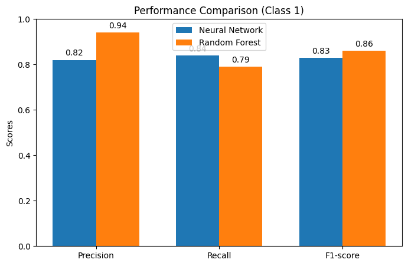

```python
import matplotlib.pyplot as plt
import numpy as np

metrics = ['Precision', 'Recall', 'F1-score']
nn_scores = [0.82, 0.84, 0.83]
rf_scores = [0.94, 0.79, 0.86]

x = np.arange(len(metrics))
width = 0.35

fig, ax = plt.subplots(figsize=(8,5))
rects1 = ax.bar(x - width/2, nn_scores, width, label='Neural Network')
rects2 = ax.bar(x + width/2, rf_scores, width, label='Random Forest')

ax.set_ylabel('Scores')
ax.set_title('Performance Comparison (Class 1)')
ax.set_xticks(x)
ax.set_xticklabels(metrics)
ax.set_ylim(0,1)
ax.legend()

for rects in [rects1, rects2]:
    for rect in rects:
        height = rect.get_height()
        ax.annotate(f'{height:.2f}',
                    xy=(rect.get_x() + rect.get_width() / 2, height),
                    xytext=(0,3),
                    textcoords='offset points',
                    ha='center', va='bottom')

plt.show()
```